# Vektorski podaci: R paket sf

Milan Kilibarda

Analiza prostorno vremenskih podataka - Master studije geoinformatike, Građevinski fakultet u Beogradu

2026-04-14

## Info grafik

[figure not shown]

## Video pregled

[video not shown]

## 🌍 Uvod u sf paket – rad sa prostornim podacima u R-u

Paket **`sf`** (*Simple Features for R*) omogućava **rad sa prostornim podacima** na **efikasan i intuitivan način** koristeći **Tidyverse sintaksu**.

**Zašto koristiti `sf`?**

- Omogućava **jednostavno čuvanje, manipulaciju i vizualizaciju prostornih podataka**.
- Podržava **različite geometrijske tipove** (tačke, linije, poligoni) i njihove kombinacije.
- **Kompatibilan je sa `tidyverse`** ( u prvom redu sa `dplyr`, `ggplot2` ), što olakšava manipulaciju i vizualizaciju podataka.
- Radi sa **standardnim formatima prostornih podataka** (`gpkg`, `GeoJSON`, `PostGIS`,`shapefile`, itd.).
- Omogućava **prostorne analize** poput preseka, bufer zona i prostornih pridruživanja … i mnoge GIS operacije.

## 🗺️ Šta su *Simple Features*?

- **Feature** = entitet ili objekt sa prostornom lokacijom → npr. zgrada, reka, ili neopipljive pojave: granice država, opština i drugo.
  - ili prostornim obuhvatom nekog entiteta (`bbox- xmin, ymin, xmax, ymax`)
- **Geometrija** opisuje prostorne osobine:
  - *Tačka* (point)
  - *Linija* (linestring, više povezanih tačaka)
  - *Poligon* (zatvorena linija)
  - *Skupovi gore pomenutih geometrijiskih primitiva*
- Osim geometrije, feature/entitet ima i **atribute**:
  - vremenski, tekstualni, kvantitativni (npr. ime, boja, temperatura, broj stanovnika, koncentracija cinka u zemljištu, klasu zemljišnog pokrivača i drugo.)

### 📊 Kada sf klase nisu prikladne?

- Kontinuirane pojave (npr. temperatura vode, nadmorska visina)

  → bolje se prikazuju **raster podacima** (polja, funkcija prostora → vrednost)

## 💾 Čuvanje geometrija u data.frame tibble

- sf objekti su **data.frame** objekti sa **posebnom kolonom** koja sadrži geometrijske informacije.
- **Jednostavan (S3) pristup** za čuvanje prostorne geometrije u `data.frame`:
  - koristi se **list-column** za geometriju
- Svaki red `data.frame`-a:
  - sadrži **atribute** (npr. ime, boja, visina, temperatura, broj stanovnika)
  - i jednu **geometriju** u obliku objekta (npr. tačka, linija, poligon, …)
  - ovakvi podaci imaju uređenu (`tidy`) strukturu.

## sf ilustracija

(Illustration (c) 2018 by [Allison Horst](https://twitter.com/allison_horst/status/1071456081308614656))

## 🧱 Klase u `sf` paketu

### 📦 Glavne klase:

- **`sf`**: `data.frame` sa jednom ili više list-kolona geometrije + atribut `sf_column`
- **`sfc`**: list-kolona sa više geometrija (feature geometries)
- **`sfg`**: pojedinačna geometrija u `sfc` list-koloni
- **`crs`**: koordinatni referentni sistem (atribut `sfc` objekta)

Struktura sf objekta

## 🧭 Hijerarhija sf objekta

```
flowchart TB
    %% Glavni čvor
    A["📦 <b> sf objekat </b> <br/> ( data.frame + sfc geometrija )"]

    %% Prvi nivo
    A --> B["📊 <b> Atributi </b> <br/> ( kolone kao u data.frame )"]
    A --> C["🗺️ <b> Geometrija </b> <br/> ( sfc - Simple Feature Column )"]

    %% Drugi nivo (geometrije)
    C --> D1["📍 POINT <br/> <i> ( tačka ) </i>"]
    C --> D2["➖ LINESTRING <br/> <i> ( linija ) </i>"]
    C --> D3["⬛ POLYGON <br/> <i> ( poligon ) </i>"]
    C --> D4["🧩 MULTI* <br/> <i> ( višestruke geometrije ) </i>"]

    %% Stilovi
    style A fill:#e3f2fd,stroke:#0d47a1,stroke-width:3px,color:#0d47a1
    style B fill:#e1f5fe,stroke:#0288d1,stroke-width:2px
    style C fill:#e1f5fe,stroke:#0288d1,stroke-width:2px

    style D1 fill:#e8f5e9,stroke:#2e7d32,stroke-width:2px
    style D2 fill:#e8f5e9,stroke:#2e7d32,stroke-width:2px
    style D3 fill:#e8f5e9,stroke:#2e7d32,stroke-width:2px
    style D4 fill:#e8f5e9,stroke:#2e7d32,stroke-width:2px
```

## 🧩 Tipovi `sfg` geometrija i struktura:

| Tip | Struktura |
| --- | --- |
| `POINT` | numerički vektor (x, y) |
| `MULTIPOINT` | matrica (tačke po redovima) |
| `LINESTRING` | matrica (tačke po redovima) |
| `POLYGON` | lista matrica: spoljašnji prsten + (0 ili više) unutrašnjih |
| `MULTILINESTRING` | lista matrica (linije kao nizovi tačaka) |
| `MULTIPOLYGON` | lista lista sa strukturom poput `POLYGON` |
| `GEOMETRYCOLLECTION` | lista od 2+ prethodnih geometrijskih objekata |

ℹ️ Sve geometrije mogu imati praznu formu → označava nedostajuću (`NA`) geometriju

## ⚙️ Ključne funkcije u `sf` paketu

- Sve funkcije i metode u `sf` paketu počinju sa **`st_`**
- `st_` označava **space-time** → tradicija preuzeta iz **PostGIS** standarda
- 🧠 *Funkcije su organizovane po tipu zadatka – od prostornih odnosa, preko konstrukcije geometrije, do uvoza i prikaza podataka.*

| 🗂️ Kategorija | 🔧 Funkcije |
| --- | --- |
| **binary predicates** | `st_contains`, `st_covers`, `st_equals`, `st_touches`, `st_intersects`, … |
| **binary operations** | `st_relate`, `st_distance` |
| **unary operations** | `st_area`, `st_length`, `st_is_valid`, `st_geometry_type`, … |
| **miscellaneous** | `st_sample`, `st_join`, `st_make_grid`, `sf_extSoftVersion`, … |
| **setters** | `st_set_crs`, `st_set_agr` |
| **constructors** | `st_sfc`, `st_sf`, `st_point`, `st_polygon`, … |
| **in-/output** | `st_read`, `st_write`, `read_sf`, `write_sf`, `st_layers` |
| **plotting** | `st_viewport`, `sf.colors`, `st_wrap_dateline` |

## 🎨 Metode za sf klase — značenje boja

Boje označavaju različite grupe funkcija:

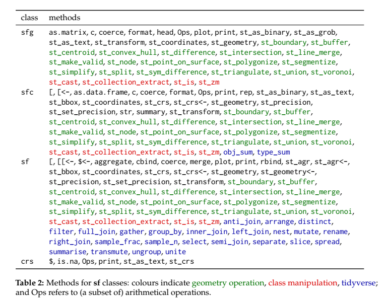

Simple Features for R: Standardized Support for Spatial Vector Data by Edzer Pebesma

## Učitavanje `sf` paketa i kreiranje objekta iz data.frame

```r
# install.packages("sf")  # Instalacija (pokrenuti samo jednom)
library(sf)

# Kreiranje prostornog objekta sa koordinatama tačaka
sf_data <- st_as_sf(
    data.frame(ime = c("Tačka 1", "Tačka 2"),
             lon = c(20.45, 19.87),
             lat = c(44.78, 45.26)), # klasičan data.frame
    coords = c("lon", "lat"), # st_as_sf očekuje kolone sa koordinatama da napravi sfc kolonu
    crs = 4326 # WGS 84 koordinatni sistem
)

# Prikaz podataka
print(sf_data)
```

```
Simple feature collection with 2 features and 1 field
Geometry type: POINT
Dimension:     XY
Bounding box:  xmin: 19.87 ymin: 44.78 xmax: 20.45 ymax: 45.26
Geodetic CRS:  WGS 84
      ime            geometry
1 Tačka 1 POINT (20.45 44.78)
2 Tačka 2 POINT (19.87 45.26)
```

## 🏗️ Geometrije podržane u okviru sf paketa – **`sfg` (Simple Feature Geometry)**

- 📍 **Tačke i grupe tačaka**
  - **`st_point()`** – pojedinačna tačka *(POINT)*
  - **`st_multipoint()`** – skup više tačaka *(MULTIPOINT)*
- 📏 **Linije i više linija**
  - **`st_linestring()`** – linija definisana nizom tačaka *(LINESTRING)*
  - **`st_multilinestring()`** – skup više linija *(MULTILINESTRING)*
- 📐 **Poligoni i više poligona**
  - **`st_polygon()`** – poligon definisan nizom koordinata *(POLYGON)*
  - **`st_multipolygon()`** – više poligona zajedno *(MULTIPOLYGON)*
- 🔄 **Raznovrsne geometrije u jednoj strukturi**
  - **`st_geometrycollection()`** – kolekcija različitih geometrijskih objekata *(GEOMETRYCOLLECTION)*